# Influencing factors and performance of YouTuber

## **Name: Rongchuan Sun (23715251)**

## **The shinny app video link**: https://youtu.be/rw1NQErea50

## **Dataset introduction**

We use the Global YouTube Statistics 2023 dataset, which can be obtained from [kaggle.com](https://www.kaggle.com/), collected by Nidula Elgiriyewithana

## Setup

Import required packages and datasets

```r
library(knitr)
library(maps)
library(broom)
library(reshape2)
library(ggplot2)
library(dplyr)
library(gridExtra)
data <- read.csv("Global YouTube Statistics 2023 dataset.csv")
```

## Data Cleaning and Transformation

Examine the dataset structure

```r
str(data)
```

```
## 'data.frame':    995 obs. of  28 variables:
##  $ rank                                   : int  1 2 3 4 5 6 7 8 9 10 ...
##  $ Youtuber                               : chr  "T-Series" "YouTube Movies" "MrBeast" "Cocomelon - Nursery Rhymes" ...
##  $ subscribers                            : int  245000000 170000000 166000000 162000000 159000000 119000000 112000000 111000000 106000000 98900000 ...
##  $ video.views                            : num  2.28e+11 0.00 2.84e+10 1.64e+11 1.48e+11 ...
##  $ category                               : chr  "Music" "Film & Animation" "Entertainment" "Education" ...
##  $ Title                                  : chr  "T-Series" "youtubemovies" "MrBeast" "Cocomelon - Nursery Rhymes" ...
##  $ uploads                                : int  20082 1 741 966 116536 0 1111 4716 493 574 ...
##  $ Country                                : chr  "India" "United States" "United States" "United States" ...
##  $ Abbreviation                           : chr  "IN" "US" "US" "US" ...
##  $ channel_type                           : chr  "Music" "Games" "Entertainment" "Education" ...
##  $ video_views_rank                       : int  1 4055159 48 2 3 4057944 5 44 630 8 ...
##  $ country_rank                           : num  1 7670 1 2 2 NaN 3 1 5 5 ...
##  $ channel_type_rank                      : num  1 7423 1 1 2 ...
##  $ video_views_for_the_last_30_days       : num  2.26e+09 1.20e+01 1.35e+09 1.98e+09 1.82e+09 ...
##  $ lowest_monthly_earnings                : num  564600 0 337000 493800 455900 ...
##  $ highest_monthly_earnings               : num  9.0e+06 5.0e-02 5.4e+06 7.9e+06 7.3e+06 ...
##  $ lowest_yearly_earnings                 : num  6.8e+06 4.0e-02 4.0e+06 5.9e+06 5.5e+06 ...
##  $ highest_yearly_earnings                : num  1.08e+08 5.80e-01 6.47e+07 9.48e+07 8.75e+07 ...
##  $ subscribers_for_last_30_days           : num  2e+06 NaN 8e+06 1e+06 1e+06 NaN NaN NaN 1e+05 6e+05 ...
##  $ created_year                           : num  2006 2006 2012 2006 2006 ...
##  $ created_month                          : chr  "Mar" "Mar" "Feb" "Sep" ...
##  $ created_date                           : num  13 5 20 1 20 24 12 29 14 23 ...
##  $ Gross.tertiary.education.enrollment....: num  28.1 88.2 88.2 88.2 28.1 NaN 88.2 63.2 81.9 88.2 ...
##  $ Population                             : num  1.37e+09 3.28e+08 3.28e+08 3.28e+08 1.37e+09 ...
##  $ Unemployment.rate                      : num  5.36 14.7 14.7 14.7 5.36 NaN 14.7 2.29 4.59 14.7 ...
##  $ Urban_population                       : num  4.71e+08 2.71e+08 2.71e+08 2.71e+08 4.71e+08 ...
##  $ Latitude                               : num  20.6 37.1 37.1 37.1 20.6 ...
##  $ Longitude                              : num  79 -95.7 -95.7 -95.7 79 ...
```

```r
summary(data)
```

```
##       rank         Youtuber          subscribers         video.views
##  Min.   :  1.0   Length:995         Min.   : 12300000   Min.   :0.000e+00
##  1st Qu.:249.5   Class :character   1st Qu.: 14500000   1st Qu.:4.288e+09
##  Median :498.0   Mode  :character   Median : 17700000   Median :7.761e+09
##  Mean   :498.0                      Mean   : 22982412   Mean   :1.104e+10
##  3rd Qu.:746.5                      3rd Qu.: 24600000   3rd Qu.:1.355e+10
##  Max.   :995.0                      Max.   :245000000   Max.   :2.280e+11
##
##    category            Title              uploads           Country
##  Length:995         Length:995         Min.   :     0.0   Length:995
##  Class :character   Class :character   1st Qu.:   194.5   Class :character
##  Mode  :character   Mode  :character   Median :   729.0   Mode  :character
##                                        Mean   :  9187.1
##                                        3rd Qu.:  2667.5
##                                        Max.   :301308.0
##
##  Abbreviation       channel_type       video_views_rank   country_rank
##  Length:995         Length:995         Min.   :      1   Min.   :   1.0
##  Class :character   Class :character   1st Qu.:    323   1st Qu.:  11.0
##  Mode  :character   Mode  :character   Median :    916   Median :  51.0
##                                        Mean   : 554249   Mean   : 386.1
##                                        3rd Qu.:   3584   3rd Qu.: 123.0
##                                        Max.   :4057944   Max.   :7741.0
##                                        NA's   :1         NA's   :116
##  channel_type_rank video_views_for_the_last_30_days lowest_monthly_earnings
##  Min.   :   1.0    Min.   :1.000e+00                Min.   :     0
##  1st Qu.:  27.0    1st Qu.:2.014e+07                1st Qu.:  2700
##  Median :  65.5    Median :6.408e+07                Median : 13300
##  Mean   : 745.7    Mean   :1.756e+08                Mean   : 36886
##  3rd Qu.: 139.8    3rd Qu.:1.688e+08                3rd Qu.: 37900
##  Max.   :7741.0    Max.   :6.589e+09                Max.   :850900
##  NA's   :33        NA's   :56
##  highest_monthly_earnings lowest_yearly_earnings highest_yearly_earnings
##  Min.   :       0         Min.   :       0       Min.   :        0
##  1st Qu.:   43500         1st Qu.:   32650       1st Qu.:   521750
##  Median :  212700         Median :  159500       Median :  2600000
##  Mean   :  589808         Mean   :  442257       Mean   :  7081814
##  3rd Qu.:  606800         3rd Qu.:  455100       3rd Qu.:  7300000
##  Max.   :13600000         Max.   :10200000       Max.   :163400000
##
```

[output cut: 9 more lines]

```
##  Min.   :  7.60                          Min.   :2.025e+05   Min.   : 0.750
##  1st Qu.: 36.30                          1st Qu.:8.336e+07   1st Qu.: 5.270
##  Median : 68.00                          Median :3.282e+08   Median : 9.365
##  Mean   : 63.63                          Mean   :4.304e+08   Mean   : 9.279
##  3rd Qu.: 88.20                          3rd Qu.:3.282e+08   3rd Qu.:14.700
##  Max.   :113.10                          Max.   :1.398e+09   Max.   :14.720
##  NA's   :123                             NA's   :123         NA's   :123
##  Urban_population       Latitude        Longitude
##  Min.   :    35588   Min.   :-38.42   Min.   :-172.10
##  1st Qu.: 55908316   1st Qu.: 20.59   1st Qu.: -95.71
##  Median :270663028   Median : 37.09   Median : -51.93
##  Mean   :224214982   Mean   : 26.63   Mean   : -14.13
##  3rd Qu.:270663028   3rd Qu.: 37.09   3rd Qu.:  78.96
##  Max.   :842933962   Max.   : 61.92   Max.   : 138.25
##  NA's   :123         NA's   :123      NA's   :123
```

```r
head(data)
```

```
##   rank                   Youtuber subscribers  video.views         category
## 1    1                   T-Series   245000000 228000000000            Music
## 2    2             YouTube Movies   170000000            0 Film & Animation
## 3    3                    MrBeast   166000000  28368841870    Entertainment
## 4    4 Cocomelon - Nursery Rhymes   162000000 164000000000        Education
## 5    5                  SET India   159000000 148000000000            Shows
## 6    6                      Music   119000000            0              nan
##                        Title uploads       Country Abbreviation  channel_type
## 1                   T-Series   20082         India           IN         Music
## 2              youtubemovies       1 United States           US         Games
## 3                    MrBeast     741 United States           US Entertainment
## 4 Cocomelon - Nursery Rhymes     966 United States           US     Education
## 5                  SET India  116536         India           IN Entertainment
## 6                      Music       0           nan          nan         Music
##   video_views_rank country_rank channel_type_rank
```

[output cut: 41 more lines]

The dataset encompasses 995 data points, spanning 28 distinct attributes.

Each illustrating attributes related to popular YouTube channels, including their rank, subscriber count, video views, and regional specifics.

Notably, each YouTube channel is uniquely identified by the ‘YouTuber’ attribute, and its performance metrics are captured through ‘subscribers’, ‘uploads’, and ‘video.views’.

The ‘category’ column suggests the niche or domain of content, while ‘Country’ hints at the geographical origin of the YouTuber, which can be critical in understanding regional trends and preferences.

Economic indicators like ‘lowest_monthly_earnings’ and ‘highest_monthly_earnings’ shed light on the potential revenue streams for these YouTubers.

Some columns contain missing data, represented by ‘NA’, which might require attention during analysis, especially in attributes like ‘video_views_rank’, ‘country_rank’, and ‘created_year’.

Addressing Data Anomalies and Extremes

```r
clean_data <- function(column) {
  if (is.numeric(column)) {
    column[is.nan(column)] <- NA
  }
   if (is.character(column)) {
    column[column == "nan"] <- NA
  }
  return(column)
}

data[] <- lapply(data, clean_data)
cols_with_zeros <- c("video.views", "lowest_monthly_earnings", "highest_monthly_earnings",
                     "lowest_yearly_earnings", "highest_yearly_earnings")

for (col in cols_with_zeros) {
  data[[col]][data[[col]] == 0] <- NA
}
```

The code first iterates through each column in the dataset to identify and handle missing values.

For numeric columns, the code checks for NaN (Not a Number) type data and replaces it with NA to ensure consistent identification of missing values in R.

For character columns, the code identifies all values labeled as “nan” and replaces them with NA.

Additionally, the code replaces zero values in columns such as video views, monthly minimum returns, monthly maximum returns, yearly minimum returns, and yearly maximum returns with NA.

In this context, zeros could be considered as missing or inaccurate data. This treatment ensures that all missing values in the dataset are uniformly represented as NA, providing a clearer and more accurate foundation for subsequent analysis.

Imputing NA Values

```r
cols_to_fill <- c("video.views", "lowest_monthly_earnings",
                  "highest_monthly_earnings", "lowest_yearly_earnings",
                  "highest_yearly_earnings", "video_views_for_the_last_30_days", "subscribers_for_last_30_days")

data <- data %>%
  group_by(Country, channel_type) %>%
  mutate(across(all_of(cols_to_fill),
                ~ ifelse(is.na(.), mean(., na.rm = TRUE), .))) %>%
  ungroup()

for (col in cols_to_fill) {
  data <- data %>%
    group_by(channel_type) %>%
    mutate_at(vars(col), ~ ifelse(is.na(.) & !is.na(channel_type),
                                  mean(., na.rm = TRUE), .)) %>%
    ungroup()
}
for (col in cols_to_fill) {
  data <- data %>%
    group_by(Country) %>%
    mutate_at(vars(col), ~ ifelse(is.na(.) & !is.na(Country),
                                  mean(., na.rm = TRUE), .)) %>%
    ungroup()
}
```

Subsequently, we conduct missing value imputation for the specified columns based on the combination of “Country” and “channel_type.” We utilize the respective means within each combination to perform the imputation.

If a particular record has a missing value in the “channel_type” column, we exclusively use the data corresponding to the associated “Country” to fill in the missing value for that record. Conversely, if the “Country” column has missing values, we solely rely on the data corresponding to the “channel_type” to perform the imputation.

This incremental approach ensures that missing values within the data are substituted with the appropriate mean under specific conditions.

```r
data <- data %>%
  mutate(Country = case_when(
    Country == "United States" ~ "USA",
    Country == "United Kingdom" ~ "UK",
    TRUE ~ Country
  ))
```

Present the Count of Missing Values in Each Column After Processing

```r
na_count <- apply(data, 2, function(x) sum(is.na(x)))
na_count
```

```
##                                    rank                                Youtuber
##                                       0                                       0
##                             subscribers                             video.views
##                                       0                                       0
##                                category                                   Title
##                                      46                                       0
##                                 uploads                                 Country
##                                       0                                     122
##                            Abbreviation                            channel_type
##                                     122                                      30
##                        video_views_rank                            country_rank
##                                       1                                     116
##                       channel_type_rank        video_views_for_the_last_30_days
##                                      33                                       0
##                 lowest_monthly_earnings                highest_monthly_earnings
##                                       0                                       0
##                  lowest_yearly_earnings                 highest_yearly_earnings
##                                       0                                       0
##            subscribers_for_last_30_days                            created_year
##                                       0                                       5
##                           created_month                            created_date
##                                       5                                       5
## Gross.tertiary.education.enrollment....                              Population
##                                     123                                     123
##                       Unemployment.rate                        Urban_population
##                                     123                                     123
##                                Latitude                               Longitude
##                                     123                                     123
```

##Data Exploration Exploring the relationship between various numerical variables

```r
numerical_cols <- c('subscribers', 'video.views', 'uploads',
                    'lowest_monthly_earnings', 'highest_monthly_earnings',
                    'lowest_yearly_earnings', 'highest_yearly_earnings',
                    'video_views_for_the_last_30_days', 'subscribers_for_last_30_days')

for (col in numerical_cols) {
    data[[col]][is.na(data[[col]])] <- mean(data[[col]], na.rm = TRUE)
}
correlation_matrix <- cor(data[, numerical_cols])
correlation_matrix
```

```
##                                  subscribers video.views    uploads
## subscribers                       1.00000000   0.7693961 0.07713566
## video.views                       0.76939611   1.0000000 0.16465794
## uploads                           0.07713566   0.1646579 1.00000000
## lowest_monthly_earnings           0.39355771   0.5419830 0.15135430
## highest_monthly_earnings          0.38556880   0.5405981 0.15733584
## lowest_yearly_earnings            0.38603409   0.5418589 0.15778702
## highest_yearly_earnings           0.38454203   0.5395327 0.15855646
## video_views_for_the_last_30_days  0.26741871   0.3601473 0.10453669
## subscribers_for_last_30_days      0.25366016   0.1636554 0.01149369
##                                  lowest_monthly_earnings
## subscribers                                    0.3935577
## video.views                                    0.5419830
## uploads                                        0.1513543
## lowest_monthly_earnings                        1.0000000
## highest_monthly_earnings                       0.9924007
## lowest_yearly_earnings                         0.9923699
## highest_yearly_earnings                        0.9895541
## video_views_for_the_last_30_days               0.6866244
## subscribers_for_last_30_days                   0.6328125
##                                  highest_monthly_earnings
## subscribers                                     0.3855688
## video.views                                     0.5405981
## uploads                                         0.1573358
## lowest_monthly_earnings                         0.9924007
## highest_monthly_earnings                        1.0000000
## lowest_yearly_earnings                          0.9998848
## highest_yearly_earnings                         0.9977310
## video_views_for_the_last_30_days                0.6930947
## subscribers_for_last_30_days                    0.6311767
##                                  lowest_yearly_earnings highest_yearly_earnings
## subscribers                                   0.3860341               0.3845420
## video.views                                   0.5418589               0.5395327
## uploads                                       0.1577870               0.1585565
## lowest_monthly_earnings                       0.9923699               0.9895541
## highest_monthly_earnings                      0.9998848               0.9977310
## lowest_yearly_earnings                        1.0000000               0.9977297
## highest_yearly_earnings                       0.9977297               1.0000000
## video_views_for_the_last_30_days              0.6930784               0.6951477
## subscribers_for_last_30_days                  0.6299383               0.6281447
##                                  video_views_for_the_last_30_days
## subscribers                                             0.2674187
## video.views                                             0.3601473
## uploads                                                 0.1045367
## lowest_monthly_earnings                                 0.6866244
## highest_monthly_earnings                                0.6930947
## lowest_yearly_earnings                                  0.6930784
## highest_yearly_earnings                                 0.6951477
## video_views_for_the_last_30_days                        1.0000000
## subscribers_for_last_30_days                            0.4272527
##                                  subscribers_for_last_30_days
## subscribers                                        0.25366016
## video.views                                        0.16365543
## uploads                                            0.01149369
## lowest_monthly_earnings                            0.63281251
## highest_monthly_earnings                           0.63117673
## lowest_yearly_earnings                             0.62993826
## highest_yearly_earnings                            0.62814471
## video_views_for_the_last_30_days                   0.42725270
## subscribers_for_last_30_days                       1.00000000
```

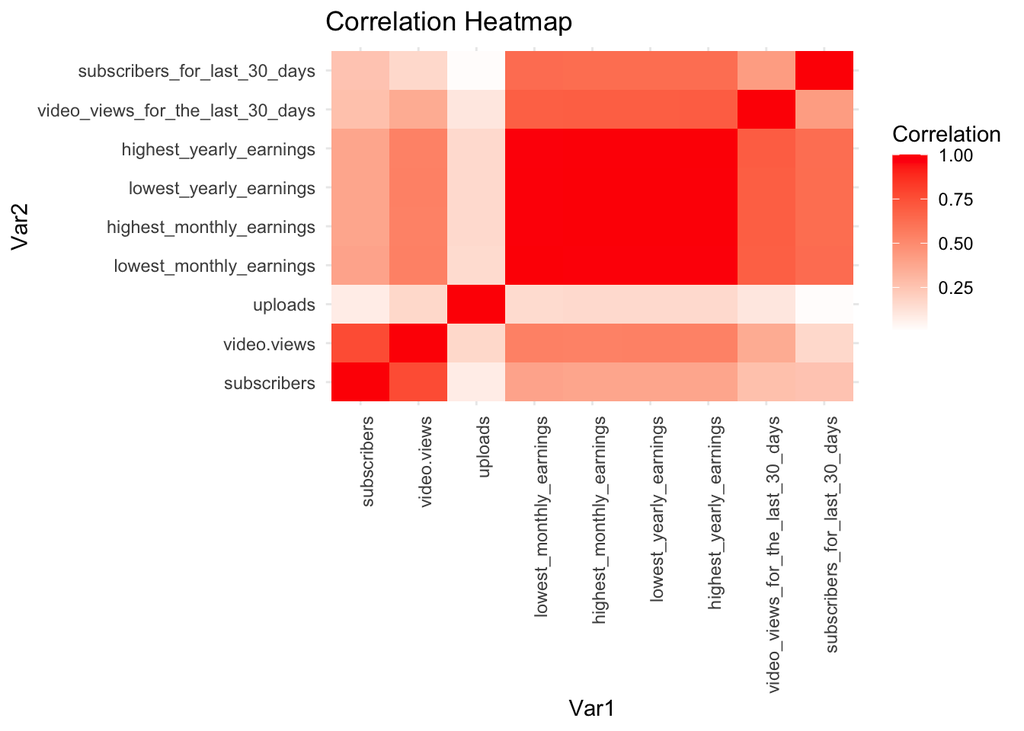

```r
melted_correlation <- melt(correlation_matrix)
my_palette <- scale_fill_gradient2(low = "blue", mid = "white", high = "red", midpoint = 0)
heatmap <- ggplot(data = melted_correlation, aes(x=Var1, y=Var2, fill=value)) +
  geom_tile() +
  my_palette +
  theme_minimal() +
  theme(axis.text.x = element_text(angle = 90, hjust = 1)) +
  labs(title="Correlation Heatmap", fill="Correlation")
heatmap
```

Identify a set of numeric columns, including: subscribers count, video views, uploads count, minimum monthly income, maximum monthly income, minimum yearly income, maximum yearly income, video views in the last 30 days, and subscribers increase in the last 30 days.

Perform a secondary round of imputation for missing values.

Provide a heatmap illustrating pairwise correlations. From the heatmap, we can observe areas where the color is deep red, indicating strong correlation between two variables. White sections represent lack of correlation. For instance, there is a strong correlation between video views and subscribers, while uploads and subscribers exhibit minimal correlation.

video.views vs. subscribers

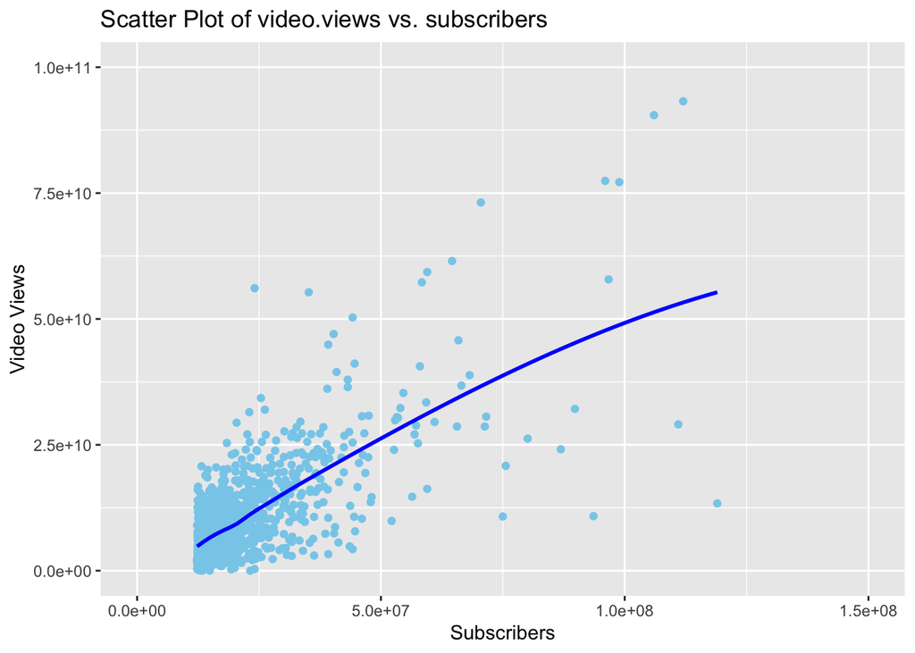

```r
ggplot(data, aes(x=subscribers, y=video.views)) +
  geom_point(color="skyblue") +
  ggtitle("Scatter Plot of video.views vs. subscribers") +
  geom_smooth(se=FALSE, color='blue') +
  xlab("Subscribers") +
  ylab("Video Views") +
  xlim(c(0, 1.5e+08)) +
  ylim(c(0, 1.0e+11))
```

The scatter plot and the trend of the fitted curve clearly demonstrate that as the number of subscribers increases, there is a corresponding increase in video views. Similarly, the reverse is also true. These two variables reinforce each other’s relationship, indicating a strong positive correlation between them.

Earnings vs. Subscribers

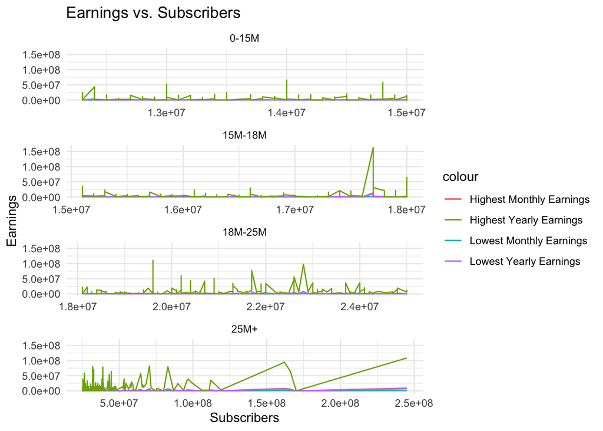

```r
bins <- c(0, 15000000, 18000000, 25000000, 245000000)
labels <- c("0-15M", "15M-18M", "18M-25M", "25M+")
data$subscriber_group <- cut(data$subscribers, breaks=bins, labels=labels, include.lowest = TRUE)

p <- ggplot(data, aes(x=subscribers)) +
  geom_line(aes(y=lowest_monthly_earnings, color="Lowest Monthly Earnings")) +
  geom_line(aes(y=highest_monthly_earnings, color="Highest Monthly Earnings")) +
  geom_line(aes(y=lowest_yearly_earnings, color="Lowest Yearly Earnings")) +
  geom_line(aes(y=highest_yearly_earnings, color="Highest Yearly Earnings")) +
  labs(title="Earnings vs. Subscribers", x="Subscribers", y="Earnings") +
  theme_minimal() +
  facet_wrap(~subscriber_group, scales = "free_x", ncol=1)
p
```

Upon stratifying the Subscribers’ count, we observe variations in the trends of all four types of income within each stratum. Notably, across the four strata, income exhibits continuous fluctuations with distinct peaks. Particularly evident is the increased frequency of these income peaks as the Subscribers’ count rises. This observation suggests a strong correlation between Subscribers and income within certain categories, while this correlation might be absent in others. To delve deeper, we can further categorize the YouTubers based on their content genres.

Earnings by Subscribers and Category

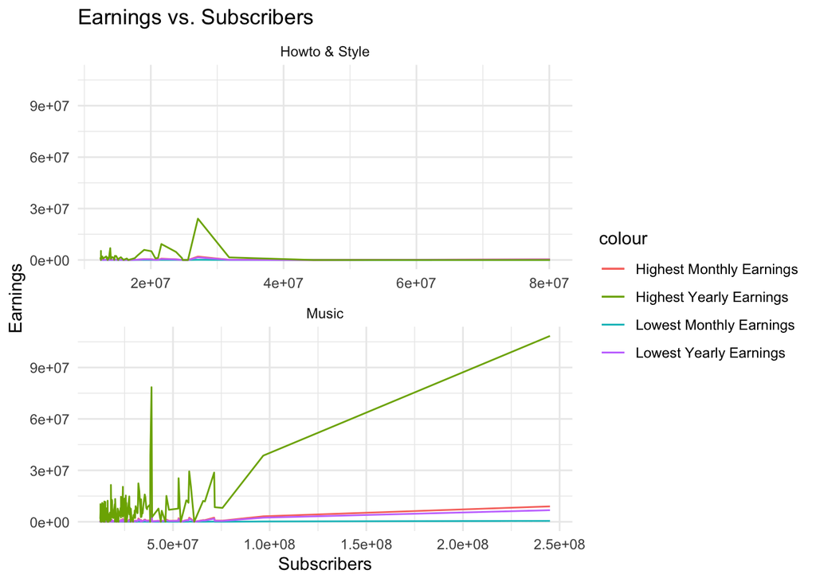

```r
plot_category <- function(data, categories) {
  data_filtered <- data %>%
    filter(category %in% categories)

  bins <- c(0, 15000000, 18000000, 25000000, 245000000)
  labels <- c("0-15M", "15M-18M", "18M-25M", "25M+")
  data_filtered$subscriber_group <- cut(data_filtered$subscribers,
                                        breaks=bins,
                                        labels=labels,
                                        include.lowest = TRUE)

  p <- ggplot(data_filtered, aes(x=subscribers)) +
    geom_line(aes(y=lowest_monthly_earnings, color="Lowest Monthly Earnings"), na.rm = TRUE) +
    geom_line(aes(y=highest_monthly_earnings, color="Highest Monthly Earnings"), na.rm = TRUE) +
    geom_line(aes(y=lowest_yearly_earnings, color="Lowest Yearly Earnings"), na.rm = TRUE) +
    geom_line(aes(y=highest_yearly_earnings, color="Highest Yearly Earnings"), na.rm = TRUE) +
    labs(title="Earnings vs. Subscribers", x="Subscribers", y="Earnings") +
    theme_minimal() +
    facet_wrap(~category, scales = "free_x", ncol=1)

  return(p)
}

p <- plot_category(data, c("Music", "Howto & Style"))
p
```

Upon further segmentation, we discern that certain content categories exhibit a robust correlation between Subscribers and income. For instance, genres like Music showcase a positive correlation, wherein income escalates with an increasing Subscribers’ count. Conversely, in categories like Howto & Style, this correlation is absent. This elucidates the recurring income fluctuations and the presence of higher peaks in all four strata. Notably, as the Subscribers’ count rises, the frequency of income peaks augments.

Youtuber geographical distribution

[figure not shown]

```r
library(ggplot2)
library(dplyr)
library(sf)
library(rnaturalearth)
library(rnaturalearthdata)
world <- ne_countries(scale = "medium", returnclass = "sf")
youtuber_count <- data.frame(Country = names(table(data$Country)), Count = as.numeric(table(data$Country)))

world_data <- left_join(world, youtuber_count, by = c("sovereignt" = "Country"))
world_data$Count[is.na(world_data$Count)] <- 0

ggplot(data = world_data) +
  geom_sf(aes(fill = Count)) +
  scale_fill_gradient(low = "white", high = "blue", name = "Number of Youtubers") +
  theme_minimal() +
  labs(title = "Distribution of Youtubers by Country")
```

Youtuber geographical distribution by Rank

```r
library(leaflet)
library(dplyr)
library(htmltools)

plot_map_for_rank <- function(rank_start, rank_end, title) {

  subset_data <- data %>%
    filter(rank >= rank_start & rank <= rank_end)

  country_counts <- subset_data %>%
    group_by(Country) %>%
    summarise(
      count = n(),
      avgLat = mean(Latitude, na.rm = TRUE),
      avgLong = mean(Longitude, na.rm = TRUE)
    ) %>%
    ungroup()

  map <- leaflet() %>%
    addTiles() %>%
    addCircleMarkers(
      data = country_counts,
      lng = ~avgLong,
      lat = ~avgLat,
      weight = 1,
      radius = ~sqrt(count) * 3,
      fillColor = "blue",
      fillOpacity = 0.5,
      popup = ~paste(Country, ": ", count, " YouTubers")
    ) %>%
    addControl(
      html = tags$div(tags$h4(title)),
      position = "topright"
    )
  return (map)
}

map1 <- plot_map_for_rank(1, 332, "Youtubers geographical distribution in High Rank")
map2 <- plot_map_for_rank(333, 666, "Youtubers geographical distribution in Mid Rank")
map3 <- plot_map_for_rank(667, 995, "Youtubers geographical distribution in Low Rank")
map1
```

[interactive chart not shown]

```r
map2
```

[interactive chart not shown]

```r
map3
```

[interactive chart not shown]

3 ranking range of Youtuber, we can find that no matter how we change the specified range, the United States and India are the countries with the most Youtube distribution. In general, the United States, India, Brazil, and the United Kingdom are the top four countries for Youtube distribution.

United State vs India vs Brazil vs United Kingdom

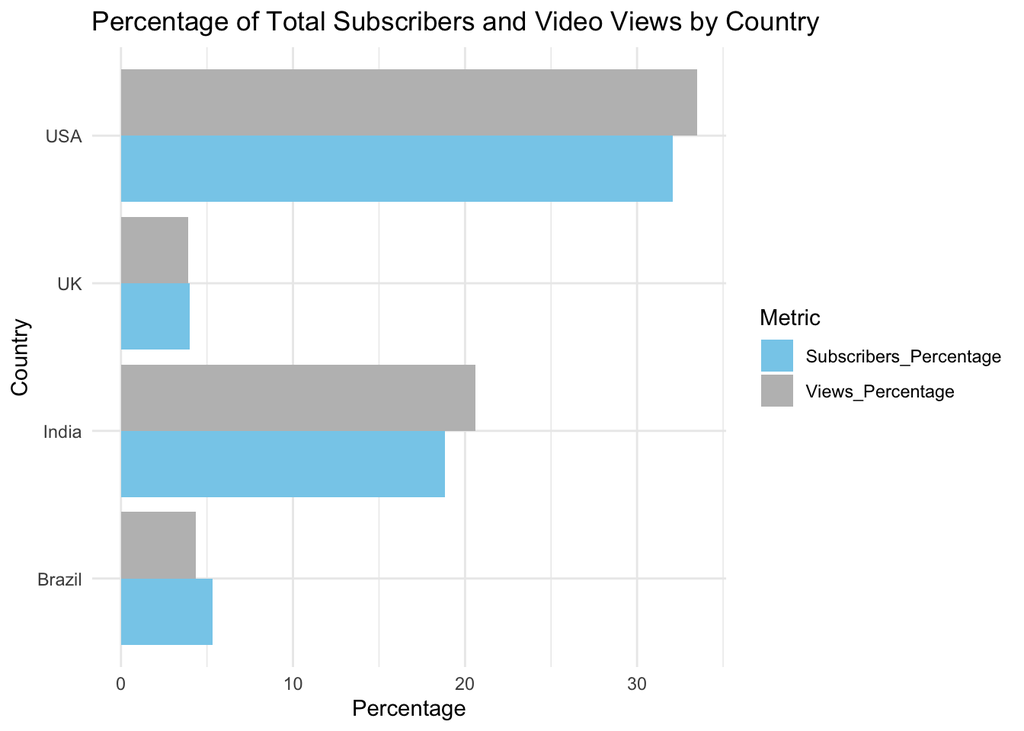

```r
country_sums <- data %>%
  group_by(Country) %>%
  summarise(Total_Subscribers = sum(subscribers, na.rm = TRUE),
            Total_Views = sum(video.views, na.rm = TRUE)) %>%
  filter(Country %in% c("USA", "India", "Brazil", "UK"))


global_sums <- data %>%
  summarise(Global_Total_Subscribers = sum(subscribers, na.rm = TRUE),
            Global_Total_Views = sum(video.views, na.rm = TRUE))

country_sums$Subscribers_Percentage <- (country_sums$Total_Subscribers / global_sums$Global_Total_Subscribers) * 100
country_sums$Views_Percentage <- (country_sums$Total_Views / global_sums$Global_Total_Views) * 100

long_country_sums <- country_sums %>%
  select(Country, Subscribers_Percentage, Views_Percentage) %>%
  tidyr::pivot_longer(cols = c(Subscribers_Percentage, Views_Percentage),
                      names_to = "Metric",
                      values_to = "Value")

library(ggplot2)

ggplot(long_country_sums, aes(x = Country, y = Value, fill = Metric)) +
  geom_col(position = "dodge") +
  coord_flip() +
  labs(title = "Percentage of Total Subscribers and Video Views by Country",
       x = "Country", y = "Percentage") +
  theme_minimal() +
  scale_fill_manual(values = c("skyblue", "grey"))
```

Youtuber Channel Type Distribution

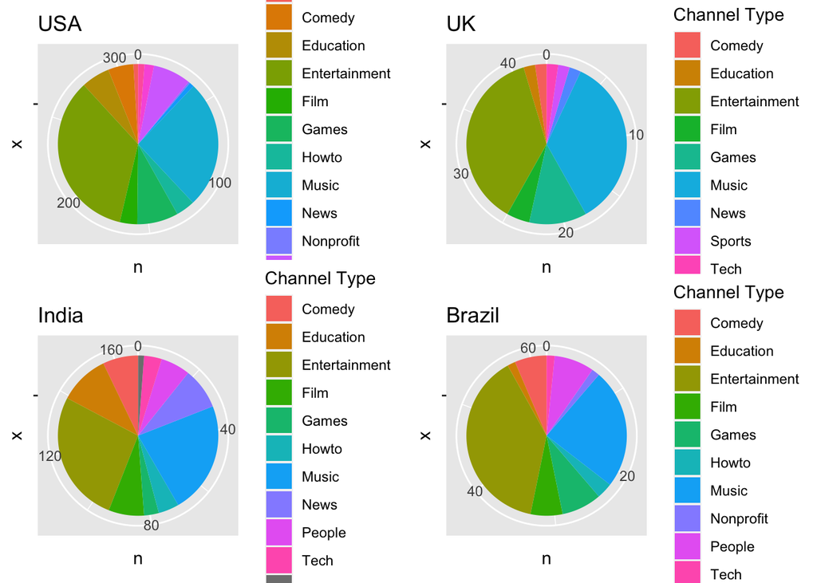

```r
library(dplyr)
library(ggplot2)
library(gridExtra)

selected_countries <- c("USA", "UK", "India", "Brazil")
filtered_data <- data %>%
  filter(Country %in% selected_countries) %>%
  group_by(Country, channel_type) %>%
  summarise(n = n())
plot_list <- lapply(selected_countries, function(country) {
  country_data <- dplyr::filter(filtered_data, Country == country)

  p <- ggplot(country_data, aes(x = "", y = n, fill = channel_type)) +
    geom_bar(stat = "identity", width = 1) +
    coord_polar(theta = "y") +
    labs(title = paste(country),
         fill = "Channel Type")
  return(p)
})

do.call(grid.arrange, plot_list)
```

Select 4 different countries to get a distribution pie chart of Youtuber categories

We can find that most national entertainment channels and music channels have the most Youtubers

Guess if music and entertainment also have the most subscribers？

Distribution of Subscribers by Category Distribution

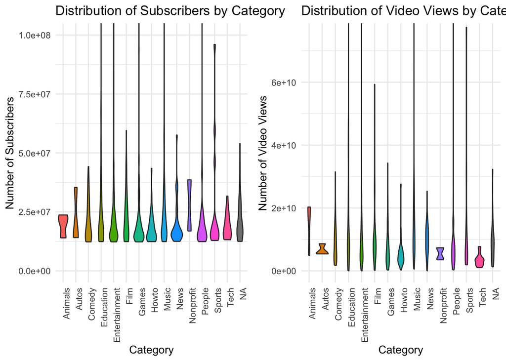

```r
library(ggplot2)
library(gridExtra)

createViolinPlot <- function(data, y_column, y_label, title_text, y_limit_upper) {

  plot <- ggplot(data, aes(x = channel_type, y = .data[[y_column]], fill = channel_type)) +
    geom_violin() +
    labs(title = title_text,
         y = y_label, x = "Category") +
    theme_minimal() +
    theme(axis.text.x = element_text(angle = 90, hjust = 1),
          legend.position = "none") +
    coord_cartesian(ylim = c(0, y_limit_upper))

  return(plot)
}


p1 <- createViolinPlot(data, "subscribers", "Number of Subscribers", "Distribution of Subscribers by Category", 1.0e+08)
p2 <- createViolinPlot(data, "video.views", "Number of Video Views", "Distribution of Video Views by Category", 7.5e+10)

grid.arrange(p1, p2, ncol = 2)
```

From the violin graph, it can be found that the average values of these two categories are not much higher than those of the others, but there are too many outliers in these two categories. The number of certain youtubers who subscribe to these two channels is particularly large, which drives the entire number of subscriptions

Youtuber Channel Type Prediction

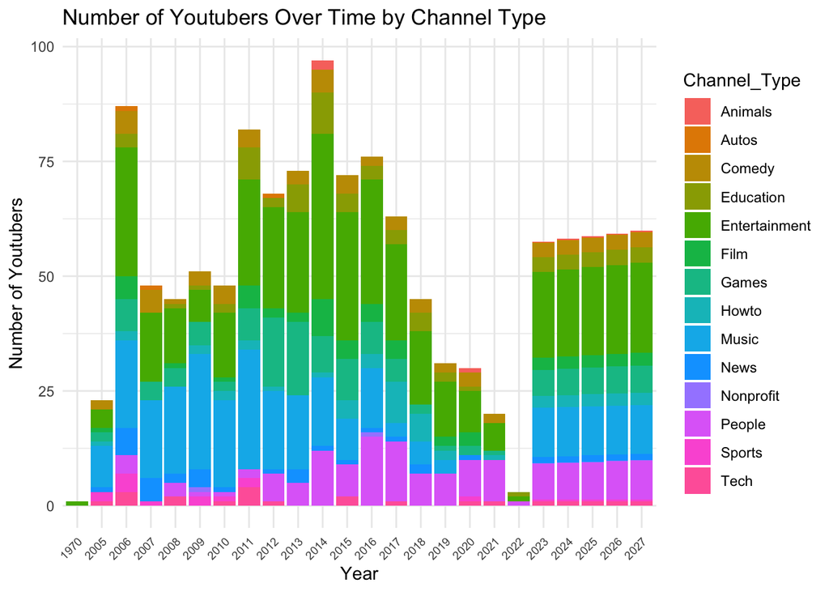

```r
freq_table <- table(data$created_year, data$channel_type)
df <- as.data.frame(as.table(freq_table))
colnames(df) <- c("Year", "Channel_Type", "Count")
df <- df[!is.na(df$Year), ]
df$Year <- as.numeric(as.character(df$Year))

predictions <- list()
for (channel in unique(df$Channel_Type)) {
  subset_data <- df[df$Channel_Type == channel,]
  model <- lm(Count ~ Year, data=subset_data)
  future_years <- (max(subset_data$Year, na.rm = TRUE) + 1):(max(subset_data$Year, na.rm = TRUE) + 5)
  predicted_counts <- predict(model, newdata=data.frame(Year=future_years))
  predictions[[channel]] <- data.frame(Year=future_years, Channel_Type=channel, Count=predicted_counts)
}

predicted_df <- do.call(rbind, predictions)
combined_data <- rbind(df, predicted_df)
ggplot(combined_data, aes(x = as.factor(Year), y = Count, fill = Channel_Type)) +
  geom_bar(stat = "identity", position = "stack") +
  labs(title = "Number of Youtubers Over Time by Channel Type",
       x = "Year",
       y = "Number of Youtubers") +
  theme_minimal()+
  theme(axis.text.x = element_text(size = 7, angle = 45, hjust = 1))
```

By analyzing the yearly count of channel creations across various categories, we can extrapolate and predict the yearly count of YouTuber creations for each channel category over the next five years. This projection allows us to infer the developmental trajectory of different channel categories.

It can be seen that the number of youtubers on entertainment channels, music channels and people channels will continue to increase steadily in the next five years

# Shiny Part

```r
library(shiny)
library(shinythemes)
library(ggplot2)
library(leaflet)
library(dplyr)

ui <- navbarPage(
  title = "YouTube Data Analysis",
  theme = shinytheme("cerulean"),

  tabPanel("Subscribers vs Uploads Analysis",
           sidebarLayout(
             sidebarPanel(
               selectInput("category",
                           label = "Choose a Category:",
                           choices = unique(data$category))
             ),
             mainPanel(
               plotOutput("categoryPlot")
             )
           )),

  tabPanel("YouTuber Distribution by Rank",
           sidebarLayout(
             sidebarPanel(
               sliderInput("rankRange", "Select Rank Range:",
                           min = 1, max = 995, value = c(1, 995))
             ),
             mainPanel(
               leafletOutput("interactiveMapRank")
             )
           )),

  tabPanel("Youtuber Channel Type Distribution",
           sidebarLayout(
             sidebarPanel(
               selectInput("selectedCountry",
                           label = "Choose a country:",
                           choices = unique(data$Country),
                           selected = unique(data$Country)[1])
             ),
             mainPanel(
               plotOutput("pieChart")
             )
           ))
)

server <- function(input, output) {
  output$categoryPlot <- renderPlot({
    df <- data %>%
      filter(category == input$category)

    ggplot(df, aes(x = uploads, y = subscribers)) +
      geom_line(aes(group = 1), color = "blue") +
      labs(title = paste("Subscribers vs Uploads for", input$category),
           x = "Number of Uploads",
           y = "Number of Subscribers") +
      theme_light() +
      theme(axis.text.x = element_text(angle = 45, hjust = 1))
  })

    output$interactiveMapRank <- renderLeaflet({

    subset_data <- data %>%
      filter(rank >= input$rankRange[1] & rank <= input$rankRange[2])

    country_counts <- subset_data %>%
      group_by(Country) %>%
      summarise(
        count = n(),
        avgLat = mean(Latitude, na.rm = TRUE),
        avgLong = mean(Longitude, na.rm = TRUE)
      ) %>%
      ungroup()

    leaflet() %>%
      addTiles() %>%
      addCircleMarkers(
        data = country_counts,
        lng = ~avgLong,
        lat = ~avgLat,
        weight = 1,
        radius = ~sqrt(count) * 3,
        fillColor = "blue",
        fillOpacity = 0.5,
        popup = ~paste(Country, ": ", count, " YouTubers")
      )
  })

  output$pieChart <- renderPlot({
    selected_data <- dplyr::filter(data, Country == input$selectedCountry)

    channel_count <- selected_data %>%
      group_by(channel_type) %>%
      summarise(n = n())

    ggplot(channel_count, aes(x = "", y = n, fill = channel_type)) +
      geom_bar(stat = "identity", width = 1) +
      coord_polar(theta = "y") +
      labs(title = paste("Youtuber Channel Type Distribution in", input$selectedCountry),
           fill = "Channel Type")
  })
}

shinyApp(ui = ui, server = server)
```

Shiny applications not supported in static R Markdown documents